# 1 Expeditionary Innovation

Exploratory and confirmatory experiments to find and fill unknown, unmet needs

## 1.1 Navigating the Innovation Terrain with more than Intuition

Innovation, while exhilarating, is fraught with challenges and uncertainties. The path to successful innovation is rarely a straight line; it’s a journey that requires navigating through the unknown, transforming obscurity into clarity. Our innate intuition often compels us to jump headfirst into solution-building. However, this approach, akin to Reid Hoffman’s metaphor of building a plane while plummeting off a cliff, often leads us astray. The reality is that many innovations fail not due to flawed execution but because they aim to solve the wrong problem — a problem that might not even exist.

### 1.1.1 Escaping the Solution-First Trap

The allure of the solution-first approach is understandable. It’s a path trodden by numerous successful innovations, shaping our lives in profound ways. Consider the birth of Google: Larry Page and Sergei Brin didn’t start by identifying a market need; they began with a mathematical fascination. Their exploration of the web’s link structure led to the PageRank algorithm, fundamentally changing how we access information. This narrative, however, is more an exception than the rule.

For every Google, countless other ventures have followed this intuitive path only to encounter failure. The story of Webvan serves as a cautionary tale. Their assumption that most customers would embrace online grocery shopping led to a massive investment in infrastructure. However, this ambitious expansion was predicated on an untested assumption about customer behavior, ultimately leading to their downfall.

### 1.1.2 An Evidence-Based Approach to Innovation

Enter the lean startup method, an approach that tests intuitive, solution-first ideas with experiments. It advocates for a hypothesis-driven, experimental process where learning and adaptation take precedence over blind execution. This method, rooted in lean manufacturing principles, involves continuous testing and validation, focusing on learning from customer feedback and adapting accordingly.

Take Zappos as an example. Instead of investing heavily in inventory and infrastructure, they started by simply testing customer willingness to buy shoes online. This low-cost experiment provided valuable insights, laying the groundwork for what would become a billion-dollar business.

The lean startup method, while reducing the cost and time of failure, does not inherently increase the probability of an idea’s success. It facilitates a quicker cycle of hypothesis testing, allowing entrepreneurs to pivot efficiently until they find a viable path. However, it often operates on the principle that all hypotheses are equally viable, leading to a trial-and-error approach.

### 1.1.3 An Exploratory Approach to Innovation

In contrast, to the lean startup method, *expeditionary innovation* offers a strategy that elevates the quality of hypotheses. It focuses on deeply understanding customer needs first, thereby increasing the likelihood of developing solutions that genuinely address these needs. This approach doesn’t just accelerate the process of innovation; it directs efforts towards areas with a higher probability of success.

Expeditionary innovation is not just about failing fast; it’s about informed exploration. It’s about gathering insights that hone in on areas ripe for innovation, where the probability of finding valuable solutions is significantly higher. This book aims to guide you through the entrepreneurial innovation process, emphasizing the importance of customer-centric exploration in generating high-probability hypotheses for success. As we delve deeper into this journey, we’ll explore practical strategies and frameworks that enable innovators to discover and solve problems worth solving, transforming the daunting landscape of innovation into a terrain of opportunity and impact.

## 1.2 Expeditionary Innovation: Embracing Uncertainty in the Innovation Process

Expeditionary innovation represents the journey of navigating the uncharted territories of customer needs and market opportunities.[^1] Unlike traditional approaches that often start with a solution in search of a problem, expeditionary innovation embraces uncertainty by exploring the unknown and replacing it with the newly known. It’s about embarking on an explorative quest to uncover hidden problems worth solving and then devising solutions with a higher probability of success.

### 1.2.1 Uncertainty in Innovation

Uncertainty is an intrinsic aspect of innovation, resembling a journey into uncharted territory. Innovating under these conditions is like navigating through a wilderness where the clear paths and visible peaks of value are hidden, shrouded in the fog of the unknown.

Yet, this fog of uncertainty presents not just challenges, but opportunities for exploration and discovery. It’s within this uncertainty that creativity and innovation thrive. You can’t directly see the peaks of value, and neither can others. This presents a unique opportunity: to engage with the uncertainty, to illuminate the unseen, and to chart new paths. This process of exploration, while slower and more deliberate, offers a more assured route to innovative success.

*Expeditionary innovation* is about embracing this uncertainty and using it as a catalyst for exploration and discovery. It involves a methodical journey through the unknown, guided by insights gathered through exploratory experiments. Each step in this journey is a deliberate effort to uncover new insights and illuminate paths that lead to solutions deeply resonant with customer needs and market dynamics.

In expeditionary innovation, the central challenge is finding peaks of value in a landscape you can’t fully see. This approach replaces the daunting unknown with knowledge gained from a series of thoughtful explorations. It’s not about wandering aimlessly in the dark; it’s about progressing methodically, turning uncertainty from a barrier into a beacon that guides you towards impactful and meaningful innovation.

#### Exploratory vs. Informative Experiments

The innovative process in expeditionary innovation is characterized by two types of experiments: exploratory and informative. Exploratory experiments are akin to scouting missions, where the goal is to observe, learn, and generate knowledge about the unknown. These experiments provide the necessary illumination to form informed hypotheses about what problems exist and what solutions might be viable.

On the other hand, informative experiments are more focused, testing these formed hypotheses to validate or invalidate them. While informative experiments are crucial, their effectiveness is significantly enhanced when preceded by thorough exploratory experiments. This sequential approach ensures that the hypotheses being tested are grounded in a deeper understanding of the market and customer needs.

#### An Iterative Process of Learning and Adapting

Expeditionary innovation is inherently iterative. It’s about continually refining your understanding of the problem and the solution through a cycle of learning and adaptation. This process involves:

- Gathering insights through exploratory experiments to uncover unmet needs or new opportunities.
- Formulating hypotheses based on these insights.
- Testing these hypotheses through informative experiments.
- Learning from the outcomes, whether success or failure.
- Iterating on the solution based on feedback and new knowledge.

Expeditionary innovation offers a structured yet flexible framework for navigating the complexities of the innovation process. By emphasizing exploratory experiments to generate high-probability hypotheses and following up with informative experiments for validation, this approach maximizes the chances of creating solutions that genuinely meet customer needs and succeed in the market. As such, it is a powerful methodology for entrepreneurs and innovators who seek to turn uncertainty into opportunity and exploration into impactful innovation.

## 1.3 Expeditionary Innovation in a Typology of Innovation

Uncertainty in innovation can be categorized based on the familiarity of customer needs and the novelty of solutions. This typology helps innovators identify their approach and anticipate the challenges and opportunities each category presents.

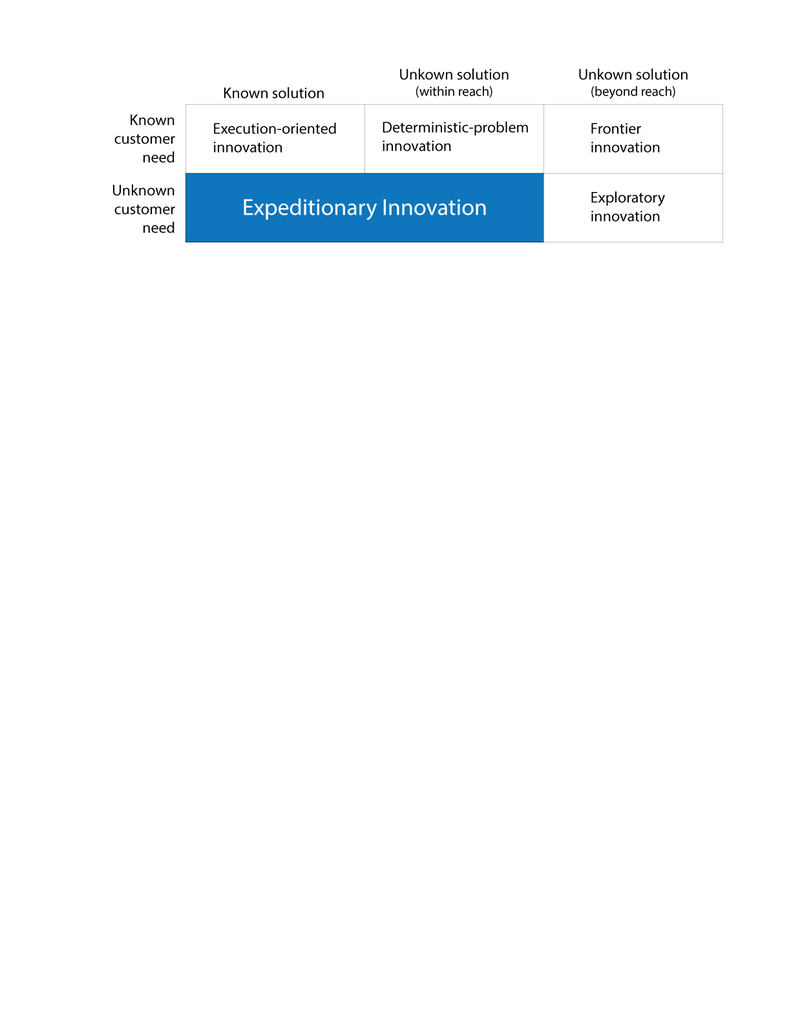

### 1.3.1 Known Customer Need

1. **Execution-Oriented Innovation (Process Innovation and Product Imitation):** When both the customer need and the solution are well-understood, innovation involves executing a known solution with efficiency and effectiveness. It’s about optimizing existing solutions, like improving manufacturing processes or adapting a successful business model to a new market. For example, a new fast-food franchise in a developing area isn’t innovating a new product but is instead adapting a proven solution to a new market context.
2. **Deterministic-Problem Innovation:** Here, the customer need is clear, but the solution is not. Innovators use their expertise to create solutions that address these known needs. For example, longer-lasting batteries for smartphones represent a deterministic-problem innovation — the need is clear, and the challenge is to develop a solution using current technological capabilities.
3. **Frontier Innovation:** Known needs but with solutions that push beyond current knowledge boundaries. These innovations often require significant scientific or technological breakthroughs. A classic example is the ongoing research into curing certain diseases; the need is evident, but the solution requires pioneering new scientific understanding.

### 1.3.2 Unknown Customer Need

1. **Expeditionary Innovation (Known Solutions):** This involves uncovering customer needs that are not immediately apparent and addressing them with existing solutions. Chobani’s introduction of Greek yogurt to the U.S. market is a prime example. The need for healthier, protein-rich breakfast options was unarticulated until Chobani identified and met it with a known product type.
2. **Expeditionary Innovation (Unknown Solutions):** Here, both the customer need and the solution are initially unknown. Innovators not only discover these latent needs but also develop new solutions to address them. The rise of ride-sharing platforms like Uber and Lyft exemplifies this, where both the customer’s desire for a different type of taxi service and the solution (a technology platform connecting drivers and passengers) were developed together.
3. **Exploratory Innovation:** This represents the most challenging form of innovation, where both the need and the solution are unknown and beyond the current knowledge frontier. Often, these innovations emerge from advanced research and lead to the creation of entirely new markets or industries. The space exploration efforts and subsequent technological advancements (like GPS technology) are examples of exploratory innovation.

### 1.3.3 Why Focus on Expeditionary Innovation?

Expeditionary innovation is particularly compelling because it often leads to the creation of new markets or significantly alters existing ones. Unlike deterministic-problem or execution-oriented innovation, where competition can be intense, expeditionary innovation allows for a first-mover advantage in newly created or redefined markets. It aligns with the entrepreneurial spirit of discovering hidden opportunities and addressing them creatively. This approach doesn’t just solve existing problems; it discovers and defines new problems, often leading to more sustainable and less competitive market positions.

The process of expeditionary innovation involves a deep understanding of potential customers and their unarticulated needs. It requires a blend of market insight, customer empathy, and the ability to think outside existing paradigms. Innovators in this space often redefine the way we think about everyday needs or uncover needs we didn’t know we had.

While expeditionary innovation with known solutions is challenging, it often doesn’t require the extensive R&D of frontier or exploratory innovation. It’s about seeing the familiar in unfamiliar ways. On the other hand, when dealing with unknown solutions, the challenge is twofold: identifying the hidden need and developing a novel solution. This dual challenge can be more complex but also more rewarding, as it allows for truly transformative innovations.

In summary, focusing on expeditionary innovation offers a strategic path for entrepreneurs. It aligns with the essential entrepreneurial skills of opportunity identification, resourcefulness, and risk management. While it requires a keen sense of observation and the ability to venture into the unknown, it holds the promise of unveiling unique market opportunities and establishing new paradigms in business and technology.

## 1.4 There Are Always Unknown Customer Needs to Unearth

The process of expeditionary innovation begins with a deep dive into the lives of a chosen group of people to discover and address their needs. This approach is rooted in the understanding that there are always unknown customer needs waiting to be discovered, a phenomenon driven by the ‘tyranny of the market’. This concept illustrates how markets, while efficient at serving the majority, often overlook the needs of those with less prevalent preferences.

### 1.4.1 Tyranny of the Market

The market tyranny arises from the tendency of companies to focus on serving mainstream customer preferences, neglecting those with unique or fringe needs. This neglect creates opportunities for entrepreneurial innovators to discover and address these unmet needs.

### 1.4.2 Heterogeneous Customer Preferences and Willingness to Pay

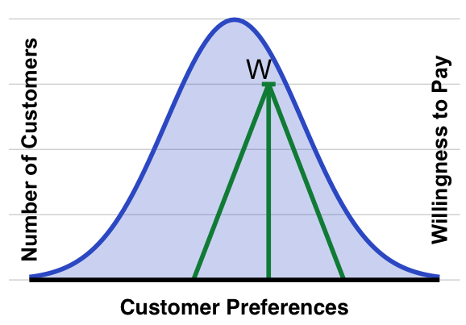

Different people want different things. It is common to assume everyone wants what the average consumer wants but this assumption is unrealistic and leads to errors in judgement. A more accurate approach is to visualize a distribution of customer preferences, where the majority may cluster around a certain point, but significant numbers have different, often unmet, preferences.

To see this, consider a graph where the x-axis defines the range of things that customers might want and the y-axis shows how many customers want any particular thing. There are many more customers in the mainstream of customer preferences than in the fringe.

A customer’s willingness to pay for a product varies depending on how closely it aligns with the customer’s individual preferences. Products that closely match these preferences command a higher willingness to pay. Products that are less aligned with the customer’s preferences result in lower willingness to pay.

### 1.4.3 Market Dynamics and Entrepreneurial Opportunities

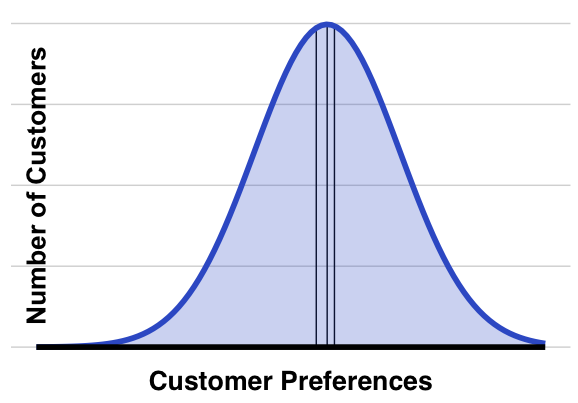

Companies tend to congregate their solutions to serve the mainstream customers in the middle of the market. Not only does this escalate competition in the market but the customers who want things that are further from the mainstream tend to get neglected; they suffer from the tyranny of the market. You can be assured that there are always neglected customers you can discover and serve better. From the very rich to the very poor, almost all customers are willing to pay at least a small premium for a product that better satisfies their personal preferences. Expeditionary innovation thrives in these neglected spaces.

### 1.4.4 Profitability and Positioning:

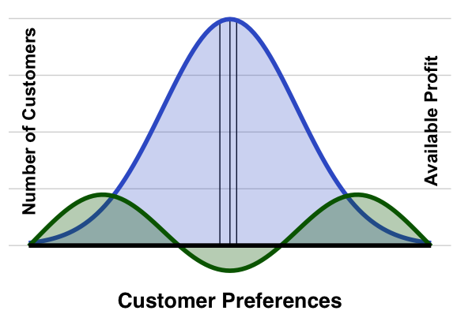

Choosing to serve these neglected customer segments can be more profitable than competing in the overcrowded mainstream market. Positioning near incumbents to serve the mainstream customers will typically result in low or even negative profits. In contrast, neglected customers suffering the tyranny of the market will be grateful for a solution that serves them better and they will gladly pay you a premium for your better solution. If there are enough customers who have that need and want that product, they will reward you for freeing them from the tyranny of the market. The green areas in the graphical representation symbolize the higher profitability potential in serving these segments. By moving away from mainstream customers and toward fringe customers who are eager to pay to finally have their needs met, innovators can find greater profitability.

The lean startup method, while effective in confirming customer interest, doesn’t guarantee optimal market positioning. Innovators using this method risk being outmaneuvered by competitors who identify and target better positions based on a deeper understanding of customer needs.

The key takeaway for entrepreneurs is the assurance that there are always opportunities to find unmet customer needs, especially among those neglected by the tyranny of the market. By focusing on these underserved segments, innovators can create solutions that not only meet unique needs but also unlock new areas of profitability and market growth. The challenge and opportunity lie in accurately identifying these segments and developing solutions that resonate with their specific preferences.

## 1.5 Expanded View of the Scientific Method for Expeditionary Innovation

### 1.5.1 Traditional Scientific Method

The traditional scientific method has been pivotal in advancing our understanding of the natural world and shaping numerous technological breakthroughs.[^2] Its structured approach to questioning, hypothesizing, testing, analyzing, and iterating is foundational in any rigorous inquiry process. Here’s a brief overview of its steps:

1. **Questioning:** Identifying knowledge gaps and formulating pertinent questions.
2. **Hypothesizing:** Developing testable conjectures based on existing knowledge.
3. **Testing:** Designing experiments to validate or invalidate hypotheses.
4. **Analysis:** Interpreting results to refine hypotheses and understanding.
5. **Repetition:** Conducting iterative experiments to build upon findings.

In well-established scientific fields, these steps are applied within the context of existing theories and knowledge, providing a clear roadmap for inquiry. However, in the context of expeditionary innovation, where we often venture into uncharted territories, a broader, more adaptive approach is required.

### 1.5.2 Defining Exploratory Experiments

Exploratory experiments are characterized by their open-ended, discovery-oriented nature.[^3] They often precede the formulation of precise hypotheses, serving as a means to gather insights, identify patterns, and generate new questions. These experiments are not solely aimed at confirming or refuting established theories but are designed to expand the horizon of understanding in areas where existing knowledge is limited or non-existent.

### 1.5.3 Key Features of Exploratory Experiments

1. **Exploration Over Confirmation:** Unlike conventional experiments that test specific hypotheses, exploratory experiments are more about observing, learning, and discovering new phenomena. They often start without preconceived theories, making them ideal for investigating unknown territories.
2. **Adaptability and Flexibility:** These experiments are inherently adaptable. They evolve in response to new findings, unexpected results, or emerging insights, often leading to shifts in direction or focus.
3. **Instrument and Method Development:** Exploratory experiments frequently necessitate the creation or refinement of new experimental tools or methods. They push the boundaries of existing techniques, paving the way for novel approaches to data collection and analysis.
4. **Complementarity with Other Methods:** While exploratory in nature, these experiments can be effectively combined with more structured, hypothesis-testing methods. They often lay the groundwork for further, more focused inquiry.
5. **Embracing Uncertainty:** Given their exploratory nature, the outcomes of these experiments can be less definitive or more open to interpretation. This aspect is not a drawback but a reflection of the complex and nuanced nature of exploring the unknown.
6. **Interdisciplinary Integration:** The flexible and open-ended approach of exploratory experiments makes them particularly valuable in interdisciplinary research, where they can bridge diverse fields and methodologies.

### 1.5.4 Implementing Exploratory Experiments in Expeditionary Innovation

In the context of expeditionary innovation, exploratory experiments play a crucial role in navigating the uncertainties inherent in the innovation process. They allow innovators to:

- Systematically explore customer needs and market dynamics that are not yet fully understood.
- Test a wide range of ideas and concepts in a preliminary way to gauge their potential.
- Gather rich, qualitative data that can inform the development of more targeted, hypothesis-driven experiments.
- Adapt and refine their innovation strategies based on emergent insights and understanding.

By integrating exploratory experiments into the innovation process, innovators can effectively transform uncertainty from a barrier into an opportunity for discovery and learning. This approach aligns with the broader philosophy of expeditionary innovation, where the journey of exploration and the insights gathered along the way are as valuable as the destination itself.

### 1.5.5 Generating Informed Hypotheses through Abduction

#### Concept of Abduction

Abduction is the process of generating hypotheses in expeditionary innovation. Unlike deduction or induction, abduction is a creative and speculative form of reasoning that seeks the best explanation for observed phenomena. This method is particularly relevant when dealing with uncharted territories of innovation, where surprises and unexpected observations are commonplace.

#### Process of Abductive Reasoning

1. **Observation:** Begins with noticing an unexpected or surprising fact or phenomenon.
2. **Hypothesis Generation:** Formulates a hypothesis that could explain the observation.
3. **Hypothesis Evaluation:** Assesses the hypothesis for fit, simplicity, explanatory power, and other virtues.
4. **Deduction and Prediction:** Deduces specific predictions that follow from the hypothesis.
5. **Testing and Validation:** Employs further observations or experiments to test these predictions.
6. **Iterative Refinement:** Continually improves the hypothesis based on new insights and validations.

#### Role in Expeditionary Innovation

Abduction is the bridge between the insights gathered from exploratory experiments and the formulation of testable hypotheses. It allows innovators to creatively infer potential explanations for the phenomena observed during exploratory phases and then to refine these hypotheses through iterative processes.

### 1.5.6 Validation by Traditional Experiments: Testing and Confirming Hypotheses

#### Integration with Traditional Scientific Method

Once a hypothesis is formulated through abduction, it’s subjected to the traditional scientific method for testing and validation. This includes:

1. **Designing Experiments:** Crafting experiments that can effectively test the hypothesis.
2. **Conducting Experiments:** Implementing these experiments and collecting data.
3. **Analyzing Results:** Interpreting the data to ascertain the validity of the hypothesis.

#### Effectiveness in Innovation

This approach is especially effective in innovation because it builds on a foundation of understanding gained from exploratory experiments. Innovators illuminate parts of the unknown landscape through these explorations, allowing for more informed and focused hypotheses.

In expeditionary innovation, the process is ongoing. The understanding of customer needs and the alignment of solutions are continually refined through cycles of exploration, hypothesis generation, testing, and validation. This iterative process ensures that the innovation evolves in close alignment with customer needs and market dynamics.

By focusing first on understanding customers and their needs, especially those that are not well-articulated or understood, expeditionary innovation aims to develop solutions that genuinely address these needs. Although initial solutions may be imperfect, the ongoing process of probing, refining, and validating ensures a progressively better fit between the innovation and the market.

In summary, expeditionary innovation leverages the power of exploratory experiments and abductive reasoning to generate hypotheses that are grounded in a deep understanding of uncharted customer needs. This approach is then rigorously tested and refined through traditional scientific methods, ensuring a solution that is both innovative and closely aligned with market requirements.

## 1.6 Use a Double Diamond Structure to Facilitate Expeditionary Innovation

Expeditionary innovation involves a systematic approach that begins with the discovery of an unknown customer problem, followed by the development of a solution. This process can be effectively structured by adapting the Double Diamond design process, originally developed by the Design Council in London.

### 1.6.1 The Double Diamond Design Process

The process is visually represented by two diamonds, each signifying a stage of the innovation journey. The first diamond focuses on the discovery and definition of the problem, while the second diamond is dedicated to the development and delivery of the solution.

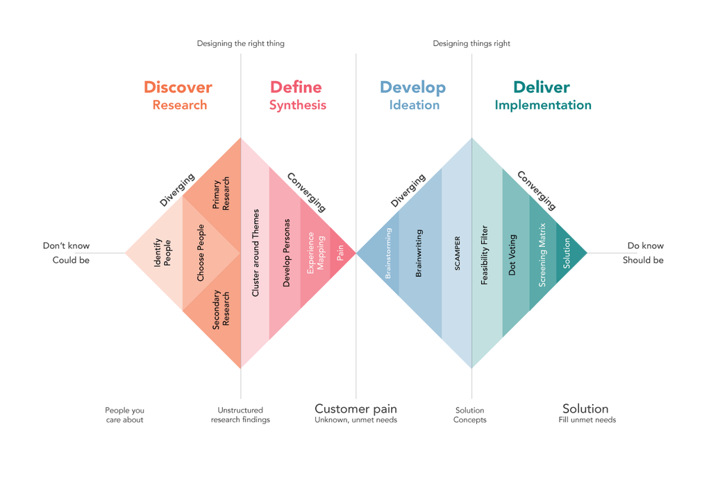

The essence of the Double Diamond process is rooted in divergent and convergent thinking. This approach echoes Linus Pauling’s insight on creativity: to arrive at good ideas, one must first explore a multitude of possibilities, and then skillfully sift through them to find the most viable ones.

This structured approach ensures that every aspect of innovation - from understanding the customer’s unmet needs to crafting a solution that effectively addresses these needs - is thoroughly explored and validated. It aligns with the ethos of expeditionary innovation, emphasizing the importance of both creative exploration and focused execution.

### 1.6.2 Discover and Define the Customer Problem:

In the first diamond, we diverge and converge to find an unknown customer need. In the divergent stage, use exploratory experiments to collect a mountain of data. In the convergent stage, use abduction to generate an informed hypothesis about an unmet need. Finally, test the hypothesis with an informative validation test.

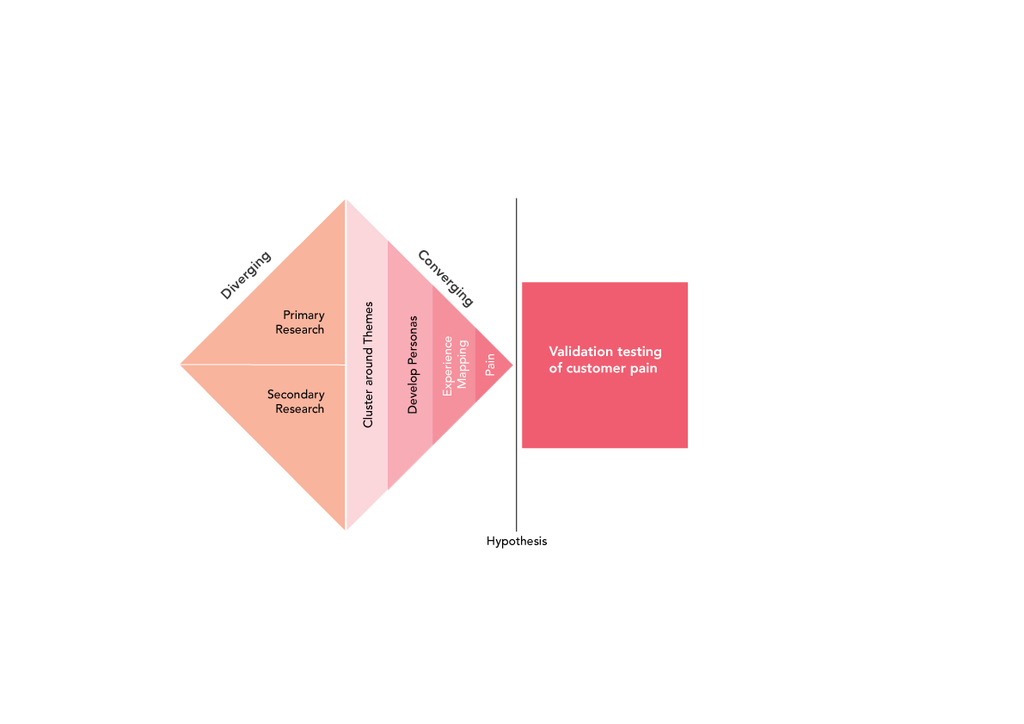

1. **Choose a Community of People:** Begin by considering many possible groups of people and then converge to choose a community of people to study. Test whether you can reach them.
2. **Explore the Community through Research:** Use exploratory experiments to gather information through primary (ethnographic) and secondary research to gain insight into their needs.
3. **Define Unmet Needs Through Empathy:** Use abduction to analyze the data to identify common themes and and define the most salient unmet needs. This generates a hypothesis of customer pains to solve.
4. **Test the Hypothesized Pain:** Conduct a traditional, informative test that validates the customer pain hypothesis.

### 1.6.3 Develop and Deliver a Solution:

In the second diamond, we diverge and converge to find a solution to the validated customer pain. In the divergent stage, use creativity tools as exploratory experiments to generate many possible solutions. In the convergent stage, use evaluation tools as abduction to generate an informed hypothesis about a solution for the unmet need. Finally, test the solution hypothesis with an array of informative tests.

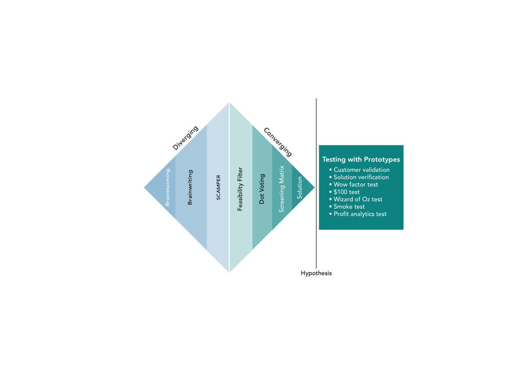

The double diamond experiment structure clarifies the roadmap for innovators to navigate the complexities of expeditionary innovation. By methodically moving through the stages of problem discovery, definition, solution development, and delivery, innovators can effectively transform uncertainty into actionable insights, leading to solutions that are not only innovative but also resonate deeply with their target customers.

Bertolotti, Tommaso. 2015. “Models in Action: An Eco-Cognitive Outlook on Experimental Science.” *Patterns of Rationality: Recurring Inferences in Science, Social Cognition and Religious Thinking*, 67–86.

Burian, Richard M. 2007. “On MicroRNA and the Need for Exploratory Experimentation in Post-Genomic Molecular Biology.” *History and Philosophy of the Life Sciences*, 285–311.

Hacking, Ian. 1983. *Representing and Intervening: Introductory Topics in the Philosophy of Natural Science*. Cambridge University Press.

Popper, Karl R. 1959. *The Logic of Scientific Discovery*. Hutchinson & Co.

Steinle, Friedrich. 1997. “Entering New Fields: Exploratory Uses of Experimentation.” *Philosophy of Science* 64 (S4): S65–74.